# Homework02

Avery Shepherd

3/22/2021

```r
library(tidyverse)
```

```r
library(cowplot)
```

## Challenge 01

```r
f <- "https://raw.githubusercontent.com/difiore/ADA-datasets/master/IMDB-movies.csv"
d <- read_csv(f,  col_names = T)
```

```r
new_d <- d %>% filter(startYear >= 1920 & startYear <= 1979) %>%
  filter(runtimeMinutes <= 180 & runtimeMinutes >= 60) %>%
  mutate(decade = case_when(startYear >= 1920 & startYear < 1930 ~ "20s",
                          startYear >= 1930 & startYear < 1940 ~ "30s",
                          startYear >= 1940 & startYear < 1950 ~ "40s",
                          startYear >= 1950 & startYear < 1960 ~ "50s",
                          startYear >= 1960 & startYear < 1970 ~ "60s",
                          startYear >= 1970 & startYear < 1980 ~ "70s"))
new_d
```

```
## # A tibble: 5,651 x 11
##    tconst titleType primaryTitle startYear runtimeMinutes genres averageRating
##    <chr>  <chr>     <chr>            <dbl>          <dbl> <chr>          <dbl>
##  1 tt001… movie     The Cabinet…      1920             76 Fanta…           8.1
##  2 tt001… movie     Leaves From…      1920            167 Drama            6.7
##  3 tt001… movie     Dr. Jekyll …      1920             82 Drama…           7
##  4 tt001… movie     The Golem         1920             76 Fanta…           7.2
##  5 tt001… movie     The Last of…      1920             73 Actio…           6.7
##  6 tt001… movie     The Mark of…      1920            107 Adven…           7.1
##  7 tt001… movie     The Penalty       1920             90 Crime…           7.4
##  8 tt001… movie     The Saphead       1920             77 Comedy           6.2
##  9 tt001… movie     Way Down Ea…      1920            145 Drama…           7.4
## 10 tt001… movie     Why Change …      1920             90 Comed…           6.7
## # … with 5,641 more rows, and 4 more variables: numVotes <dbl>, nconst <chr>,
## #   director <chr>, decade <chr>
```

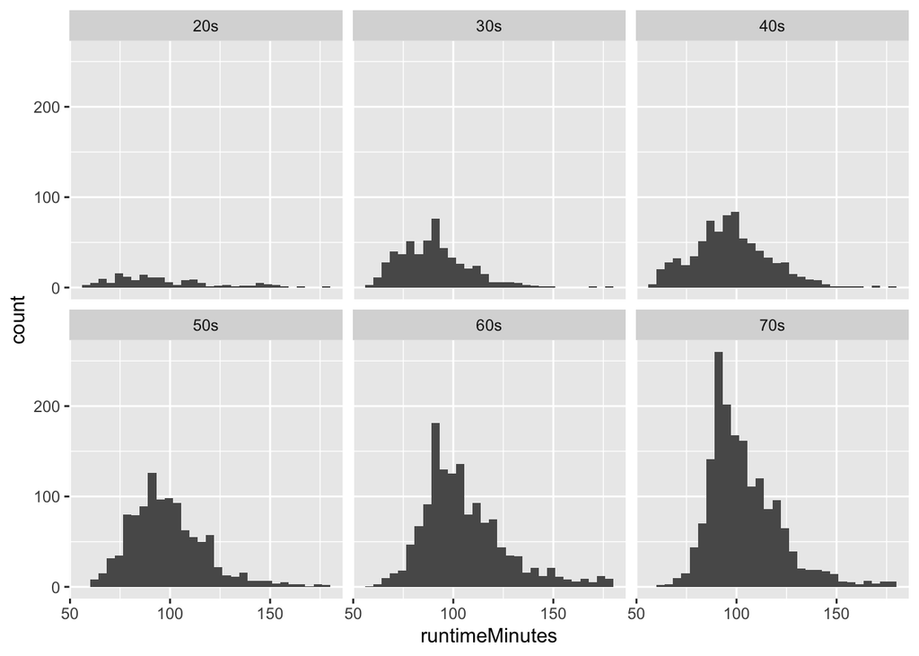

```r
new_d %>% ggplot(aes(x = runtimeMinutes)) +
  geom_histogram() +
  facet_wrap(~ decade)
```

Use a one-line statement to calculate the population mean and population standard deviation in runtimeMinutes for each decade and save the results in a new dataframe, results.

```r
pop_sd <- function(x) {
  sqrt((length(x)-1)/length(x)) * sd(x)
}
results <- new_d %>% group_by(decade) %>% summarise(runtime_mean = mean(runtimeMinutes), std_dev = pop_sd(runtimeMinutes), name = "pop")
results
```

```
## # A tibble: 6 x 4
##   decade runtime_mean std_dev name
## * <chr>         <dbl>   <dbl> <chr>
## 1 20s            96.3    26.1 pop
## 2 30s            90.3    17.3 pop
## 3 40s            97.2    19.1 pop
## 4 50s            98.9    19.2 pop
## 5 60s           106.     21.2 pop
## 6 70s           104.     18.0 pop
```

Draw a single sample of 100 movies, without replacement, from each decade, calculate this single sample mean and sample standard deviation in runtimeMinutes, and estimate the SE around the population mean runtimeMinutes for each decade based on the standard deviation and sample size from these samples.

```r
set.seed(100)
sample_results <- new_d %>% group_by(decade) %>% sample_n(100) %>% summarise(runtime_mean = mean(runtimeMinutes), std_dev = sd(runtimeMinutes), name = "sample")
```

Compare these estimates to the actual population mean runtimeMinutes for each decade and to the calculated SE in the population mean for samples of size 100 based on the population standard deviation for each decade.

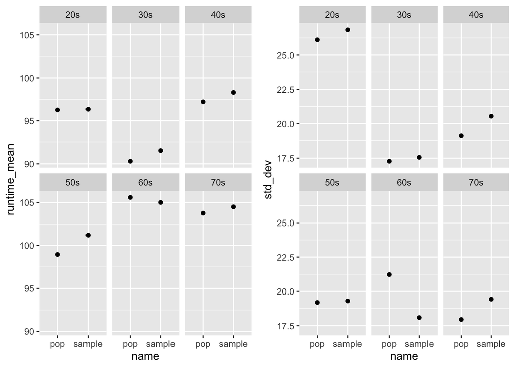

```r
p1 <- rbind(sample_results, results) %>%
  ggplot(aes(x = name, y = runtime_mean)) + geom_point() + facet_wrap(~decade)
p2 <- rbind(sample_results, results) %>%
  ggplot(aes(x = name, y = std_dev)) + geom_point() + facet_wrap(~decade)
plot_grid(p1, p2)
```

Generate a sampling distribution of mean runtimeMinutes for each decade by [a] drawing 1000 samples of 100 movies from each decade and, for each sample, [b] calculating the mean runtimeMinutes and the standard deviation in runtimeMinutes

```r
s <- data.frame()
for (i in 1:1000) {
  smple <- new_d %>% group_by(decade) %>% sample_n(100) %>% summarise(runtime_mean = mean(runtimeMinutes), std_dev = sd(runtimeMinutes), sample_num = i)
  s <- rbind(s, smple)
}
```

Then, calculate the MEAN and the STANDARD DEVIATION of the sampling distribution of sample means for each decade (the former should be a very good estimate of the population mean, while the latter is another estimate of the standard error in the population mean for a particular sample size)

```r
(distribution_results <- s %>% group_by(decade) %>% summarise(runtime_mean = mean(runtime_mean), std_dev = sd(std_dev), name = "distribution"))
```

```
## # A tibble: 6 x 4
##   decade runtime_mean std_dev name
## * <chr>         <dbl>   <dbl> <chr>
## 1 20s            96.2    1.14 distribution
## 2 30s            90.3    1.49 distribution
## 3 40s            97.2    1.42 distribution
## 4 50s            99.0    1.75 distribution
## 5 60s           106.     1.87 distribution
## 6 70s           104.     1.80 distribution
```

plot a histogram of the sampling distribution. What shape does it have?

**normally distributed**

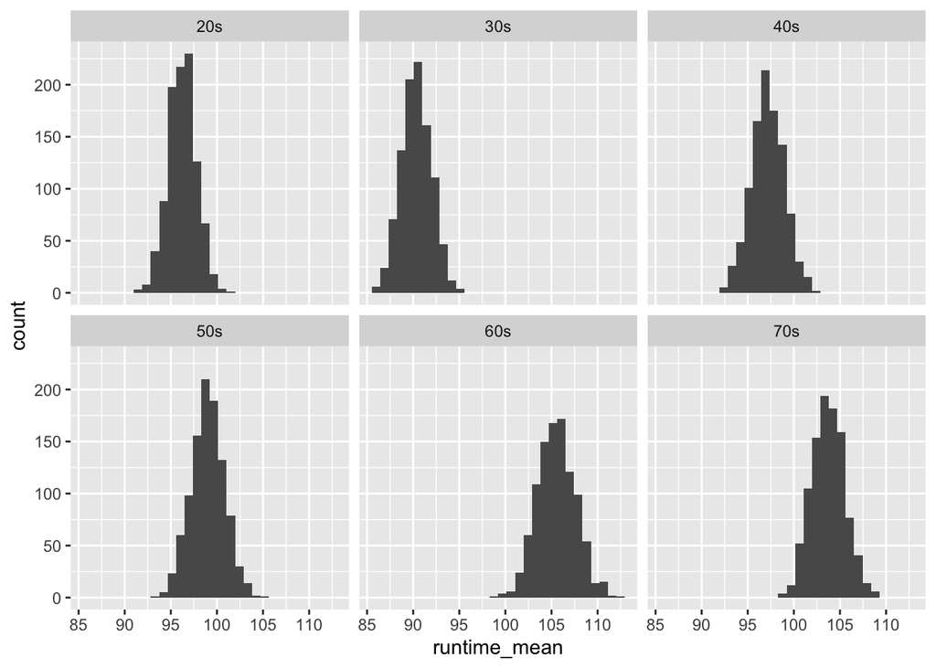

```r
ggplot(s, aes(x = runtime_mean)) + geom_histogram() + facet_wrap(~ decade)
```

Finally, compare the standard error in runtimeMinutes for samples of size 100 from each decade [1] as estimated from your first sample of 100 movies, [2] as calculated from the known population standard deviations for each decade, and [3] as estimated from the sampling distribution of sample means.

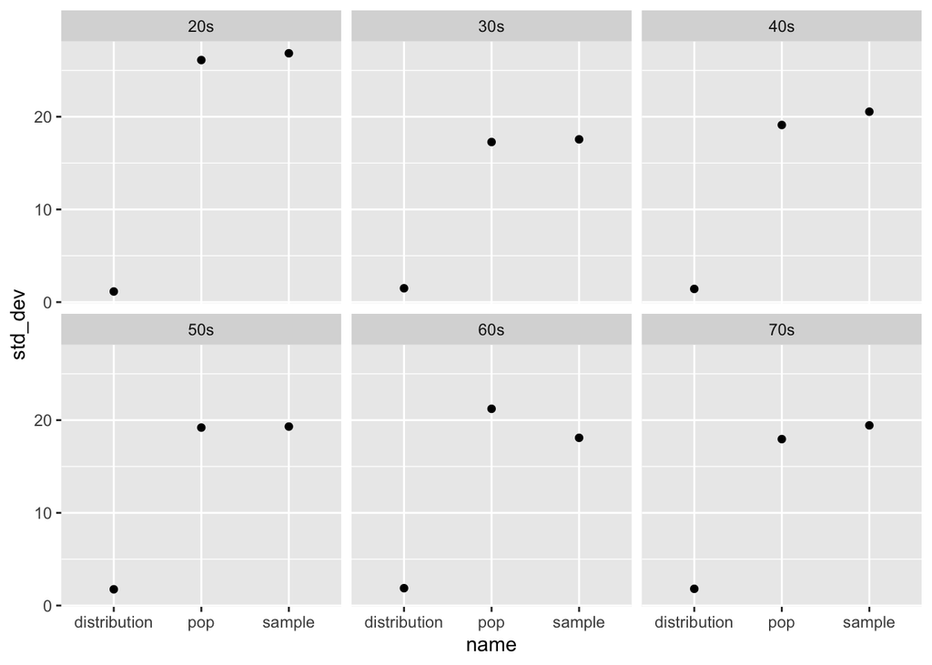

```r
standard_errors <- rbind(sample_results, results, distribution_results)
ggplot(data = standard_errors, aes(x = name, y = std_dev)) +
  geom_point() + facet_wrap(~ decade)
```

## Challenge 02

What is the probability that she will see 9 or fewer bees arrive during any given session?

```r
l = 6
x = c(0:9)
sum(dpois(x, l))
```

```
## [1] 0.916076
```

What is the probability that she will see no bees arrive in a session?

```r
x = 0
dpois(x, l)
```

```
## [1] 0.002478752
```

What is the probability that she will see exactly 5 bees arrive in a session?

```r
x = 5
dpois(x, l)
```

```
## [1] 0.1606231
```

What is the probability that she will see more than 18 bees arrive in a session?

```r
x = c(0:18)
1 - sum(dpois(x, l))
```

```
## [1] 1.759704e-05
```

Plot the relevant Poisson mass function over the values in range 0 ≤ x ≤ 24.

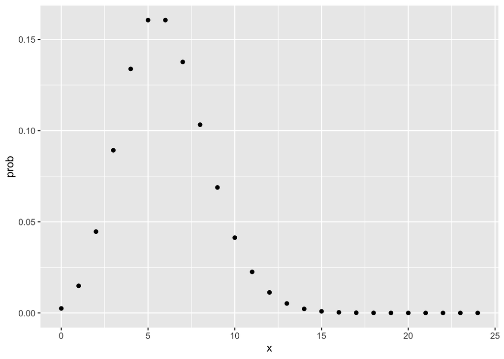

```r
x <- c(0:24)
prob <- dpois(x, l)
data.frame(cbind(x, prob)) %>% ggplot(aes(x, prob)) + geom_point()
```

## Challenge 03

```r
f <- "https://raw.githubusercontent.com/difiore/ada-2021-datasets/master/zombies.csv"
d <- read_csv(f, col_names = T)
```

Calculate the population mean and standard deviation for each quantitative random variable (height, weight, age, number of zombies killed, and years of education). Use {ggplot} and make boxplots of each of these variables by gender

```r
d %>% summarise(m_height = mean(height),
                m_weight = mean(weight),
                m_age = mean(age),
                m_kills = mean(zombies_killed),
                m_edu = mean(years_of_education))
```

```
## # A tibble: 1 x 5
##   m_height m_weight m_age m_kills m_edu
##      <dbl>    <dbl> <dbl>   <dbl> <dbl>
## 1     67.6     144.  20.0    2.99  3.00
```

```r
d %>% summarise(sd_height = pop_sd(height),
                sd_weight = pop_sd(weight),
                sd_age = pop_sd(age),
                sd_kills = pop_sd(zombies_killed),
                sd_edu = pop_sd(years_of_education))
```

```
## # A tibble: 1 x 5
##   sd_height sd_weight sd_age sd_kills sd_edu
##       <dbl>     <dbl>  <dbl>    <dbl>  <dbl>
## 1      4.31      18.4   2.96     1.75   1.68
```

Use {ggplot} and make boxplots of each of these variables by gender.

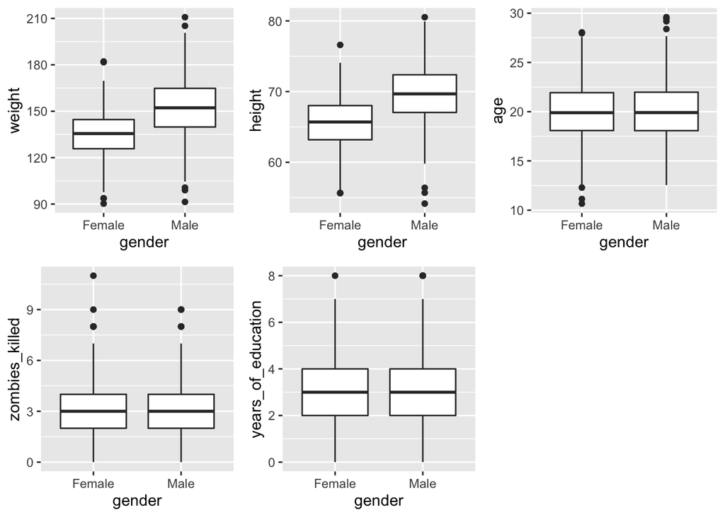

```r
plot_grid(ggplot(d, aes(x = gender, y = weight)) + geom_boxplot(),
          ggplot(d, aes(x = gender, y = height)) + geom_boxplot(),
          ggplot(d, aes(x = gender, y = age)) + geom_boxplot(),
          ggplot(d, aes(x = gender, y = zombies_killed)) + geom_boxplot(),
          ggplot(d, aes(x = gender, y = years_of_education)) + geom_boxplot())
```

Use {ggplot2} and make scatterplots of height and weight in relation to age, using different colored points for males versus females. Do these variables seem to be related? In what way?

**seem to be positively linearly related**

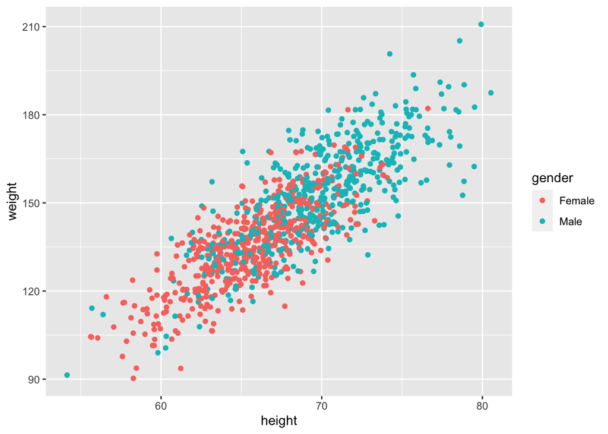

```r
ggplot(d, aes(x = height, y = weight, color = gender)) + geom_point()
```

Using histograms and Q-Q plots, check whether the quantitative variables seem to be drawn from a normal distribution. Which seem to be and which do not?

**kills and education seem to be right skewed, perhaps from a geometric distribution**

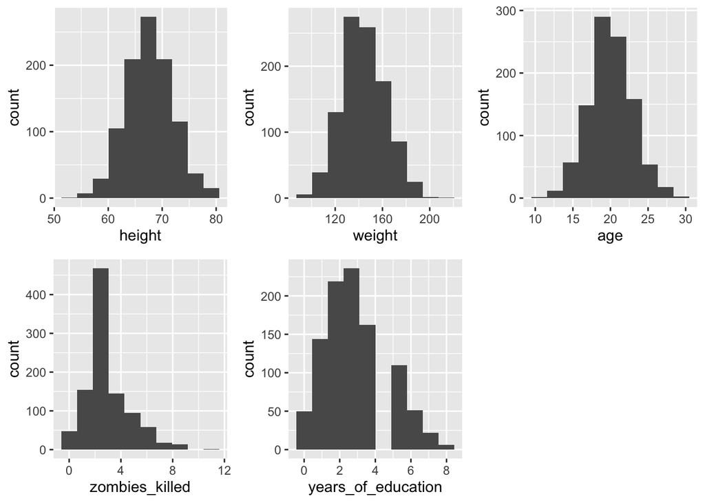

```r
plot_grid(ggplot(d, aes(x = height)) + geom_histogram(bins = 10),
          ggplot(d, aes(x = weight)) + geom_histogram(bins = 10),
          ggplot(d, aes(x = age)) + geom_histogram(bins = 10),
          ggplot(d, aes(x = zombies_killed)) + geom_histogram(bins = 10),
          ggplot(d, aes(x = years_of_education)) + geom_histogram(bins = 10),
          label = c("height", "weight", "age", "kills", "edu"))
```

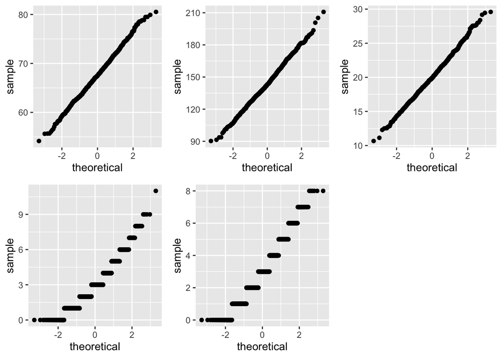

```r
plot_grid(ggplot(d, aes(sample = height)) + stat_qq(),
          ggplot(d, aes(sample = weight)) + stat_qq(),
          ggplot(d, aes(sample = age)) + stat_qq(),
          ggplot(d, aes(sample = zombies_killed)) + stat_qq(),
          ggplot(d, aes(sample = years_of_education)) + stat_qq(),
          label = c("height", "weight", "age", "kills", "edu"))
```

Now use the sample_n() function from {dplyr} to sample ONE subset of 50 zombie apocalypse survivors (without replacement) from this population and calculate the mean and sample standard deviation for each variable. Also estimate the standard error for each variable based on this sample and use that to construct a 95% confidence interval for each mean.

```r
set.seed(100)
zombie_sample <- d %>% sample_n(50)
samp_sd <- zombie_sample %>% summarise(sd_height = sd(height),
                sd_weight = sd(weight),
                sd_age = sd(age),
                sd_kills = sd(zombies_killed),
                sd_edu = sd(years_of_education))
sam_sum <- zombie_sample %>% summarise(m_height = mean(height),
                m_weight = mean(weight),
                m_age = mean(age),
                m_kills = mean(zombies_killed),
                m_edu = mean(years_of_education),
                se_height=sd(height) / sqrt(50),
                se_weight=sd(weight) / sqrt(50),
                se_age=sd(age) / sqrt(50),
                se_kills=sd(zombies_killed) / sqrt(50),
                se_edu=sd(years_of_education) / sqrt(50))
ci_95 <- function(m, se) {
  m + c(-1, 1) + qnorm(1- .05 / 2) * se
}
(ci_sam <- sam_sum %>% summarise(height = ci_95(m_height, se_height),
                                weight = ci_95(m_weight, se_weight),
                                age = ci_95(m_age, se_age),
                                kills = ci_95(m_kills, se_kills),
                                edu = ci_95(m_edu, se_edu), source = "sample"))
```

```
## # A tibble: 2 x 6
##   height weight   age kills   edu source
##    <dbl>  <dbl> <dbl> <dbl> <dbl> <chr>
## 1   68.4   152.  19.9  2.08  2.53 sample
## 2   70.4   154.  21.9  4.08  4.53 sample
```

Then draw another 99 random samples of 50 zombie apocalypse survivors out and calculate the mean for each of the these samples. Together with the first sample you drew out, you now have a set of 100 means for each variable (each based on 50 observations), which constitutes a sampling distribution for each variable. What are the means and standard deviations of the sampling distribution for each variable?

```r
zombies_distribution <- data.frame()
for (i in 1:99) {
  smple <- d %>% sample_n(50) %>% summarise(m_height = mean(height),
                m_weight = mean(weight),
                m_age = mean(age),
                m_kills = mean(zombies_killed),
                m_edu = mean(years_of_education),
                se_height = sd(height),
                se_weight = sd(weight),
                se_age = sd(age),
                se_kills = sd(zombies_killed),
                se_edu = sd(years_of_education))
  zombies_distribution <- rbind(zombies_distribution, smple)
}
zombies_distribution <- rbind(zombies_distribution, sam_sum)

dist_sum <- zombies_distribution %>% summarise(m_height = mean(m_height),
                m_weight = mean(m_weight),
                m_age = mean(m_age),
                m_kills = mean(m_kills),
                m_edu = mean(m_edu),
                se_height = sd(se_height),
                se_weight = sd(se_weight),
                se_age = sd(se_age),
                se_kills = sd(se_kills),
                se_edu = sd(se_edu))
```

Finally, construct an 95% confidence interval for each mean directly from the sampling distribution of sample means using the central 95% that distribution

```r
(ci_dist <- dist_sum %>% summarise(height = ci_95(m_height, se_height),
                                weight = ci_95(m_weight, se_weight),
                                age = ci_95(m_age, se_age),
                                kills = ci_95(m_kills, se_kills),
                                edu = ci_95(m_edu, se_edu), source = "dist"))
```

```
## # A tibble: 2 x 6
##   height weight   age kills   edu source
##    <dbl>  <dbl> <dbl> <dbl> <dbl> <chr>
## 1   67.8   148.  19.8  2.45  2.37 dist
## 2   69.8   150.  21.8  4.45  4.37 dist
```

How do the standard deviations of the sampling distribution for each variable compare to the standard errors estimated from your first sample of size 50?

**the sampling distibution has a much lower standard deviation than the one sample**

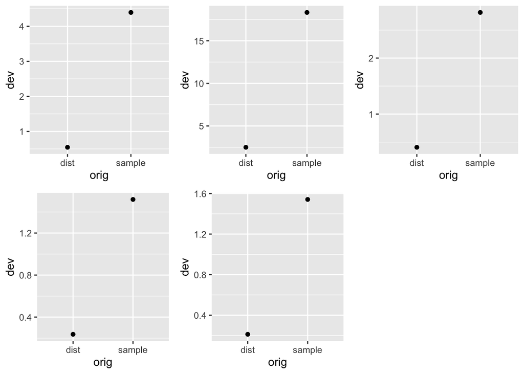

```r
weight <- data.frame(dev = c(samp_sd$sd_weight, dist_sum$se_weight), orig = c("sample", "dist")) %>% ggplot(aes(x = orig, y = dev)) + geom_point()
height <- data.frame(dev = c(samp_sd$sd_height, dist_sum$se_height), orig = c("sample", "dist")) %>% ggplot(aes(x = orig, y = dev)) + geom_point()
age <- data.frame(dev = c(samp_sd$sd_age, dist_sum$se_age), orig = c("sample", "dist")) %>% ggplot(aes(x = orig, y = dev)) + geom_point()
kills <- data.frame(dev = c(samp_sd$sd_kills, dist_sum$se_kills), orig = c("sample", "dist")) %>% ggplot(aes(x = orig, y = dev)) + geom_point()
edu <- data.frame(dev = c(samp_sd$sd_edu, dist_sum$se_edu), orig = c("sample", "dist")) %>% ggplot(aes(x = orig, y = dev)) + geom_point()

plot_grid(height, weight, age, kills, edu, label = c("height", "weight", "age", "kills", "edu"))
```

What do sampling distributions for each variable mean look like? Are they normally distributed? What about for those variables that you concluded were not originally drawn from a normal distribution?

**All of the variables look mostly normally distributed, though education still has a bit of a right skew. This could be because of the discrete values though.**

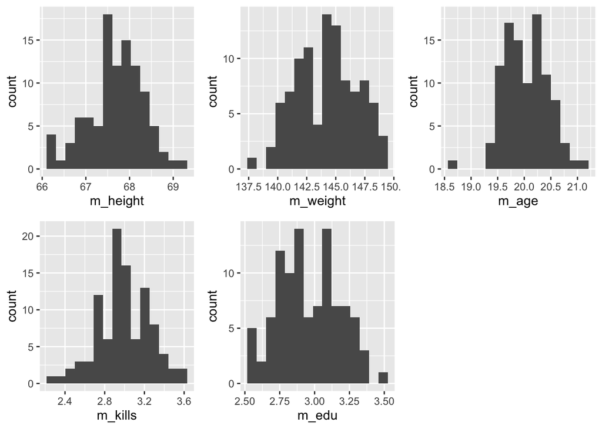

```r
plot_grid(ggplot(zombies_distribution, aes(x = m_height)) + geom_histogram(bins = 15),
          ggplot(zombies_distribution, aes(x = m_weight)) + geom_histogram(bins = 15),
          ggplot(zombies_distribution, aes(x = m_age)) + geom_histogram(bins = 15),
          ggplot(zombies_distribution, aes(x = m_kills)) + geom_histogram(bins = 15),
          ggplot(zombies_distribution, aes(x = m_edu)) + geom_histogram(bins = 15))
```

How do the two 95% CIs you estimated compare to one another (i.e., the CI based on one sample and its estimated standard deviation versus the CI based on simulation)?

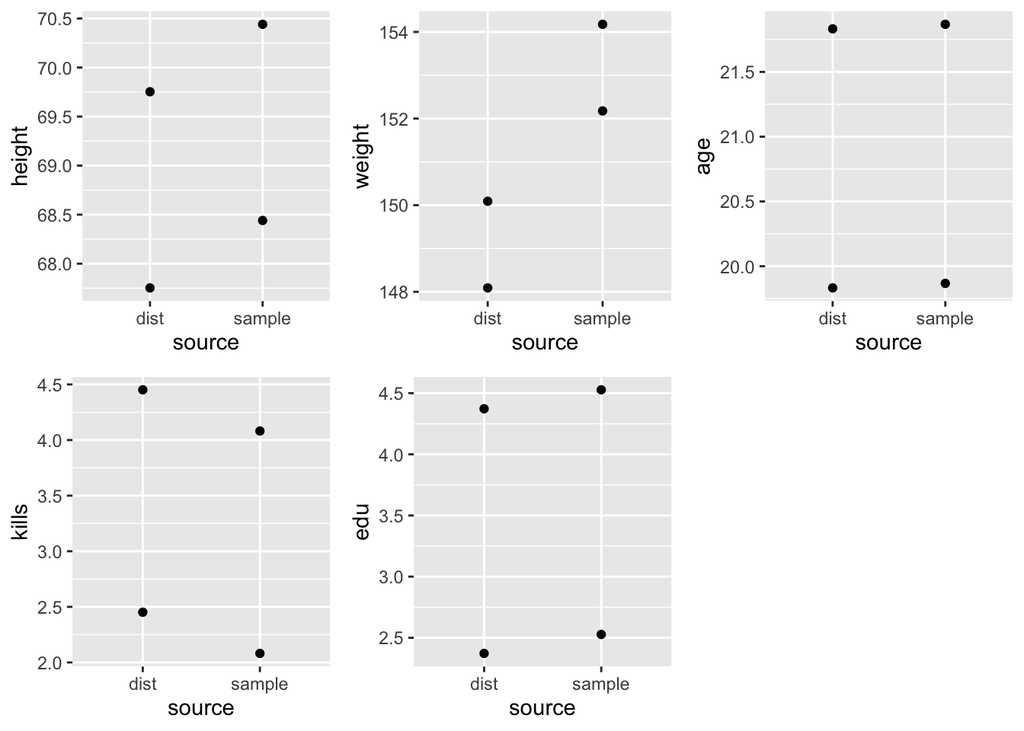

```r
ci_all <- rbind(ci_dist, ci_sam)
plot_grid(ggplot(ci_all, aes(y = height, x = source)) + geom_point(),
          ggplot(ci_all, aes(y = weight, x = source)) + geom_point(),
          ggplot(ci_all, aes(y = age, x = source)) + geom_point(),
          ggplot(ci_all, aes(y = kills, x = source)) + geom_point(),
          ggplot(ci_all, aes(y = edu, x = source)) + geom_point())
```